# Notes on Wearing and Keeling

Wearing and Keeling (2005) present the following equation for $\mathcal{R}_0$:

$$\mathcal{R}_0 = \frac{\lambda\left(\frac{\lambda}{\sigma m} + 1 \right)^m}{\gamma\left(1 - \left(\frac{\lambda}{\gamma n} + 1\right)^{-n}\right)}$$

We want to reparameterize this using generalized exponentials. First, let’s write some definitions:

- Mean infectious period: $D_I$
- Number of infectious subclasses: $n$
- Mean latent period: $D_E$
- Number of latent subclasses: $m$
- Exponential growth rate: $\lambda$
- Generalized exponential: $X_i(y) = (1 + y/i)^i$

Then, we have

$$\mathcal{R}_0 = \frac{\lambda D_I X_m(\lambda D_E) X_n(\lambda D_I)}{X_n(\lambda D_I) - 1}$$

We take one more step to simplify the equation and define the following:

- $\delta_I = \lambda D_I$
- $\delta_E = \lambda D_E$

Then, we have

$$\mathcal{R}_0 = \frac{\delta_I X_m(\delta_E) X_n(\delta_I)}{X_n(\delta_I) - 1}$$

Two observations:

- Decreasing $n$ increases $\mathcal{R}_0$.
- Decreasing $m$ decreases $\mathcal{R}_0$.

We made this argument based on the generation interval. For example, decreas8hg $m$ will make more people have faster progression to infectious period (so shorter generation interval) and have lower $\mathcal{R}_0$.

This is where using mean generation interval might not be a good idea. Svensson (2015) present an equation for mean generation interval given distribution of latent, $f_E(a)$ and infectious$f_I(a)$ periods:

$$\bar{g} = E(E) + \frac{E(I^2)}{2E(I)}$$

Now, for SEmInR model, this becomes

$$\bar{g} = D_E + \frac{1}{2}(\frac{D_I}{n} + D_I)$$

We can see that changing the shape parameter of latent distribution doesn’t have effect on mean generation. Perhaps using effective generation can help us see things better…?.

Here’s what happens when we increase $m$ (1, 3, 9) while keeping everything else constant. Vertical line represents the mean generation interval:

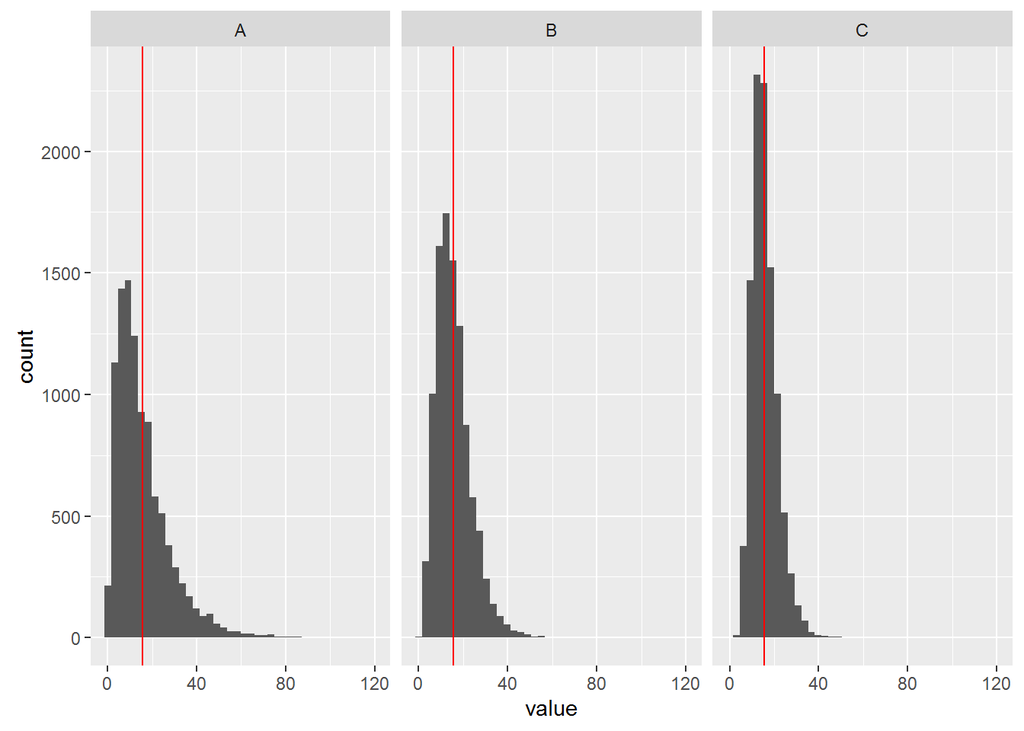

However, mean generation interval really doesn’t change:

```
## # A tibble: 3 × 2
##      L1     gbar
##   <chr>    <dbl>
## 1     A 15.66940
## 2     B 15.68794
## 3     C 15.67495
```

On the other hand, using effective mean generation interval (using arbitrary initial exponential growth rate here) can gives us clearer interpretation:

```
## # A tibble: 3 × 2
##      L1     ghat
##   <chr>    <dbl>
## 1     A 14.06141
## 2     B 14.95343
## 3     C 15.28280
```

Can we compare $R_0$ vs $r$ relationship? Dotted lines are gamma approximations:

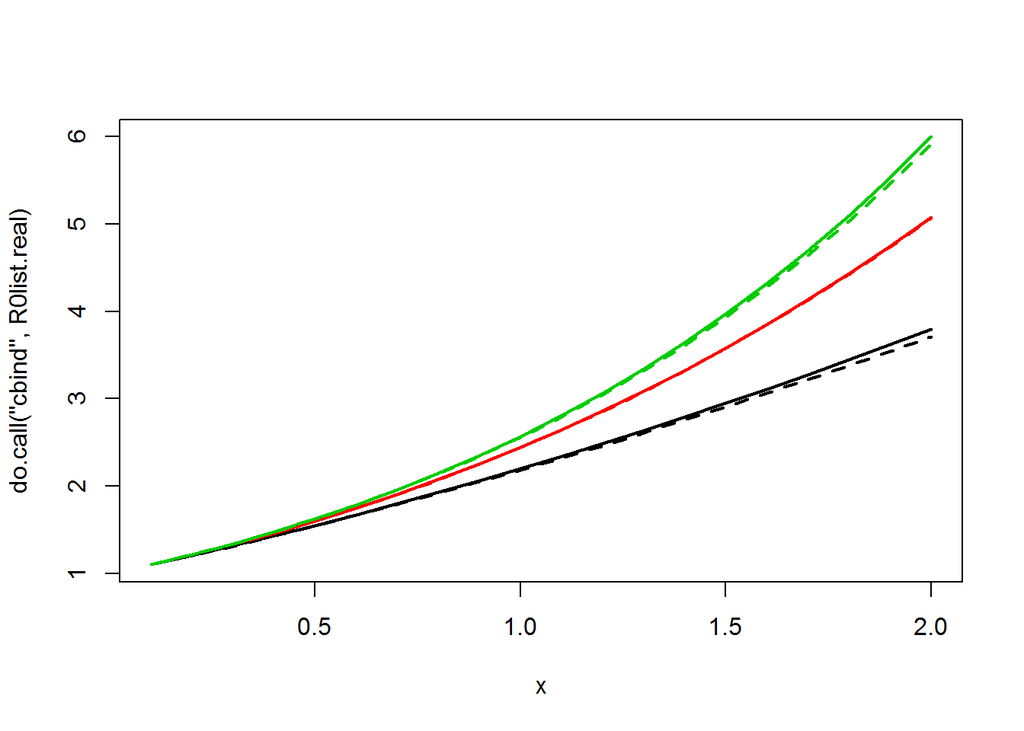

We can do this again by changing $n$ and fixing $m$. Here, we used $n = 1, 3, 9$ and $m = 1$:

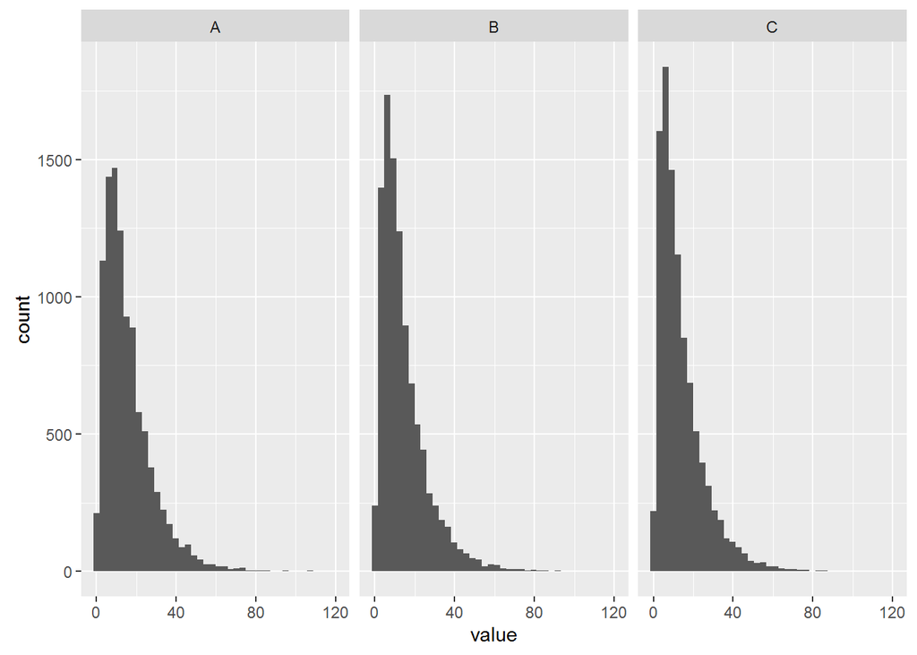

We compre mean vs effective mean generation interval (using arbitrary growth rate again):

```
## # A tibble: 3 × 3
##      L1     gbar     ghat
##   <chr>    <dbl>    <dbl>
## 1     A 15.66940 14.06141
## 2     B 14.28050 12.67649
## 3     C 13.80739 12.20234
```

Finally, r vs R0 curve:

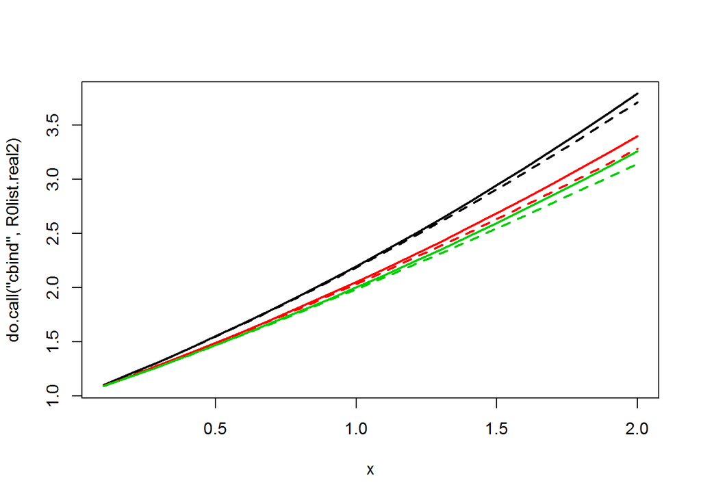